# Lecture 8

## Recap from last week

Lecture slides from last week can be found in: https://jmtfeliciano.github.io/DATA312Spring2025/Data312Spring2025_Lecture7.html

### Data recap

Last week, we went over logistic regression as a statistical model using `heart_study` data where each row corresponds to each unique patient with the following variables:

- `heart_attack` is the binary outcome we want to model (1 = had heart attack, 0 = no heart attack)
- `isFemale` is 1 if Female (0 otherwise)
- `age` is the age at the time of data collection.

```r
library(tidyverse)
# loads the heart study dataset
heart_study <- read_csv("https://raw.githubusercontent.com/jmtfeliciano/teachingdata/refs/heads/main/Data312Sp2025/heart_attack_data.csv")
head(heart_study, 10)
```

```
# A tibble: 10 × 3
   heart_attack isFemale   age
          <dbl>    <dbl> <dbl>
 1            1        1    83
 2            1        0    89
 3            1        1    99
 4            0        0    54
 5            1        0    83
 6            0        0    60
 7            0        0    38
 8            0        1    53
 9            0        0    21
10            0        0    37
```

### Model recap

**Question you may want to ask if you are a researcher:** `isFemale` a predictor of `heart_attack`? In public health language, is being Female a risk factor for heart attack (myocardial infarction)?

In last class, we built a simple logistic regression model using `glm()`.

```r
# creates the logistic regression model
model <- glm(formula = heart_attack ~ isFemale, data = heart_study, family = "binomial")
# summarizes/quantifies the model
summary(model)
```

```
Call:
glm(formula = heart_attack ~ isFemale, family = "binomial", data = heart_study)

Coefficients:
            Estimate Std. Error z value Pr(>|z|)
(Intercept)  -1.0245     0.3116  -3.288  0.00101 **
isFemale      1.3246     0.4291   3.087  0.00202 **
---
Signif. codes:  0 '***' 0.001 '**' 0.01 '*' 0.05 '.' 0.1 ' ' 1

(Dispersion parameter for binomial family taken to be 1)

    Null deviance: 135.37  on 99  degrees of freedom
Residual deviance: 125.31  on 98  degrees of freedom
AIC: 129.31

Number of Fisher Scoring iterations: 4
```

### Model interpretation

Pay close attention to `isFemale`. In particular, please note the numbers under `Estimate` (1.3246) and `Pr(>|z|)` (0.00202).

**Questions you could answer:**

1. **Is`isFemale` a statistically significant predictor or contributor to heart attack?** Yes, since P-value (0.00202) is less than 0.05.
2. **Does`isFemale` increase or decrease odds of heart attack?** First we need to exponentiate the estimate from the model: $e^{1.3246}$ = 3.760681. Since this value exceeds 1, `isFemale` increases odds of heart attack. In public health language, being female is a risk factor for heart attack.

   ```r
   # Exponentiate the estimate from the model
   exp(1.3246)
   ```

   ```
   [1] 3.760681
   ```

3. **What is the specific increase in odds (interpretation)?** The odds of having a heart attack are approximately 3.76 times greater for females than for non-females.

### Interpretation for another model

The final model we built in class assesses the impact of both `isFemale` and `age` as predictors of heart attack. This logistic regression model quantifies the simultaneous influence of both variables to the outcome of interest (heart attack).

```r
# creates the logistic regression model with two variables (isFemale + age)
final_model <- glm(formula = heart_attack ~ isFemale + age,
                   data = heart_study,
                   family = "binomial")

# summarizes/quantifies the model
summary(final_model)
```

```
Call:
glm(formula = heart_attack ~ isFemale + age, family = "binomial",
    data = heart_study)

Coefficients:
            Estimate Std. Error z value Pr(>|z|)
(Intercept) -4.14819    0.89030  -4.659 3.17e-06 ***
isFemale     1.66693    0.50884   3.276  0.00105 **
age          0.04828    0.01170   4.125 3.71e-05 ***
---
Signif. codes:  0 '***' 0.001 '**' 0.01 '*' 0.05 '.' 0.1 ' ' 1

(Dispersion parameter for binomial family taken to be 1)

    Null deviance: 135.37  on 99  degrees of freedom
Residual deviance: 103.62  on 97  degrees of freedom
AIC: 109.62

Number of Fisher Scoring iterations: 4
```

   ```r
   # exponentiated estimate for isFemale
   exp(1.66693)
   ```

   ```
   [1] 5.295884
   ```

   ```r
   # exponentiated estimate for age
   exp(0.04828)
   ```

   ```
   [1] 1.049464
   ```

   ```r
   # since age is numeric, need to use this formula
   (exp(0.04828) - 1)*100
   ```

   ```
   [1] 4.946446
   ```

3. **What is the specific increase or decrease in odds (interpretation)?**
   - After controlling for sex, we estimate that for every 1-year increase in age, the odds of having a heart attack increase by approximately 4.95%.
   - After controlling for age, we estimate the odds of having a heart attack are approximately 5.30 times greater for females than for non-females.

**Note:** In the above example, there are only two variables. However, if you are modelling using three or more variables, you may keep the language simple (e.g., “After controlling for all other variables”).

## **Formal statistical test: Which model is better?**

In model 1 above (`model`), we modeled:

```
heart_attack ~ isFemale
```

In model 2 above (`final_model`), we modeled:

```
heart_attack ~ isFemale + age
```

When you have a model that simply adds another variable on top of another model, those two models are called **nested**. When models are nested, you can formally assess the model performance via a test called likelihood ratio test. Below show you how to run the test

```r
# feed anova() with the two models to compare then add at the end: test = "LRT"
anova(model, final_model, test = "LRT")
```

```
Analysis of Deviance Table

Model 1: heart_attack ~ isFemale
Model 2: heart_attack ~ isFemale + age
  Resid. Df Resid. Dev Df Deviance  Pr(>Chi)
1        98     125.31
2        97     103.62  1   21.688 3.207e-06 ***
---
Signif. codes:  0 '***' 0.001 '**' 0.01 '*' 0.05 '.' 0.1 ' ' 1
```

**How to read the results above?**

1. **Compare the deviance:** Model 1 (isFemale) has a residual deviance of 125, while Model 2 (isFemale + age) has a residual deviance of 103. Since Model 2 has a lower residual deviance, model 2 is the better model (i.e., lower residual deviance means better fit for the underlying data). The follow-up question now becomes: is Model 2 a statistically significant better model than model 1?
2. **Look at the p-value:** Since the p-value for the Likelihood Ratio Test is less than 0.05, model 2 is a statistically significant better model than model 1.

**Again:** Likelihood ratio test is only appropriate for nested models (i.e., models that essentially builds on top of one another). In our example above, we compared `isFemale` vs `isFemale + age`).

An example of non-nested models you can’t compare via this likelihood ratio test:

Non nested model 1:

```
heart_attack ~ isFemale
```

Non nested model 2:

```
heart_attack ~ age
```

## Practice 1 (5 pts)

Using `breast_cancer_data.csv` from Canvas, build a logistic regression model to model breast cancer risk. For this first model you build, pick any variable you believe is the strongest predictor for breast cancer risk and use that variable only for your model. A word document under Week 6 is provided as a short documentation for this data set.

After you build the model, answer these questions: is the variable a statistically significant predictor or contributor to breast cancer risk? If yes, does it increase or decrease the odds of breast cancer?

> **Your answer to the questions:** Since the p-value for brca is less than 0.05, it is associated or a significant predictor of breast cancer risk. The odds for breast cancer among patients with a mother with the BRCA gene is 8.25 times greater than patients with a mother without the BRCA gene.

```r
# place your solution below
breast_cancer_data <- read_csv("data/breast_cancer_data.csv")
head(breast_cancer_data)
```

```
# A tibble: 6 × 6
  breast_cancer public_insurance   age mother_brca_gene father_lung_cancer
          <dbl>            <dbl> <dbl>            <dbl>              <dbl>
1             0                0    20                0                  0
2             1                1    60                0                  0
3             1                0    18                1                  1
4             0                0    56                0                  0
5             1                0    30                1                  0
6             0                1    22                1                  1
# ℹ 1 more variable: father_liver_cancer <dbl>
```

```r
model1 <- glm(formula = breast_cancer ~ mother_brca_gene,
              data = breast_cancer_data,
              family = "binomial")

summary(model1)
```

```
Call:
glm(formula = breast_cancer ~ mother_brca_gene, family = "binomial",
    data = breast_cancer_data)

Coefficients:
                 Estimate Std. Error z value Pr(>|z|)
(Intercept)       -0.6931     0.1682  -4.120 3.79e-05 ***
mother_brca_gene   2.1102     0.4285   4.925 8.45e-07 ***
---
Signif. codes:  0 '***' 0.001 '**' 0.01 '*' 0.05 '.' 0.1 ' ' 1

(Dispersion parameter for binomial family taken to be 1)

    Null deviance: 273.33  on 199  degrees of freedom
Residual deviance: 242.88  on 198  degrees of freedom
AIC: 246.88

Number of Fisher Scoring iterations: 4
```

```r
exp(2.1102)
```

```
[1] 8.249891
```

## Practice 2 (5 pts)

Build another model using the same data. This time, include a second variable into the model (pick another variable you believe is a strong factor/contributor to breast cancer risk.

After you build the model, answer these questions for both variables: are the variables statistically significant predictors or contributors to breast cancer risk? If yes, does they increase or decrease the odds of breast cancer?

> **Your answer to the questions:** Both BRCA and age are significant predictors of having breast cancer. Controlling for age (if you have multiple variables: “controlling for all others”), the odds of having breast cancer among patients with a mother with the BRCA gene is 8.87 times greater than patients with a mother without the BRCA gene. Controlling for BRCA gene, each year increase in age is associated with a 1.74% increase in breast cancer odds.

```r
# place your solution below
model2 <- glm(formula = breast_cancer ~ mother_brca_gene + age,
              data = breast_cancer_data,
              family = "binomial")

summary(model2)
```

```
Call:
glm(formula = breast_cancer ~ mother_brca_gene + age, family = "binomial",
    data = breast_cancer_data)

Coefficients:
                  Estimate Std. Error z value Pr(>|z|)
(Intercept)      -1.705214   0.452644  -3.767 0.000165 ***
mother_brca_gene  2.182414   0.439749   4.963 6.95e-07 ***
age               0.017206   0.006957   2.473 0.013388 *
---
Signif. codes:  0 '***' 0.001 '**' 0.01 '*' 0.05 '.' 0.1 ' ' 1

(Dispersion parameter for binomial family taken to be 1)

    Null deviance: 273.33  on 199  degrees of freedom
Residual deviance: 236.50  on 197  degrees of freedom
AIC: 242.5

Number of Fisher Scoring iterations: 4
```

```r
# this is the new estimate for BRCA
exp(2.182414)
```

```
[1] 8.867687
```

```r
# this is the new estimate for age
exp(0.017206)
```

```
[1] 1.017355
```

```r
# age interpretation for %
(exp(0.017206)-1)*100
```

```
[1] 1.735488
```

## Practice 3 (5 pts)

Which one is the better statistical model: the model you built under Practice 1 or Practice 2? And why?

Interpration: Second model is better because it has the lower residual deviance. Since the p-value of the likelihood ratio test is less than 0.05, we can conclude that the second model is also the statistically significant better model.

```r
# place your solution below
anova(model1, model2, test = "LRT")
```

```
Analysis of Deviance Table

Model 1: breast_cancer ~ mother_brca_gene
Model 2: breast_cancer ~ mother_brca_gene + age
  Resid. Df Resid. Dev Df Deviance Pr(>Chi)
1       198     242.88
2       197     236.50  1   6.3848  0.01151 *
---
Signif. codes:  0 '***' 0.001 '**' 0.01 '*' 0.05 '.' 0.1 ' ' 1
```

## Using logistic regression as a classifier

So far, we have used logistic regression as a statistical model to quantify the impact of independent variables (e.g., isFemale, age) on binary outcomes (heart attack vs no heart attack). The language of interpretation involves odds.

Some machine learning analysts or engineers use logistic regression as a classifier tool (e.g., cancer vs not cancer, spam email vs non spam email).

**How logistic regression is typically used in classifier tasks:**

1. Use some data (often called training data) to create a logistic regression model.
2. Use additional data (often called test data) to assess ability of logistic regression model to predict outcomes.
   - Calculating **probabilities** of outcome for each data row.
   - Pick a probability cut off (e.g., typically 0.50 or 50%). If 50% is picked, this is equivalent to saying: if the predicted probability for outcome exceeds 50%, you are predicted to have had a heart attack.
   - Adjust probability cut off if desired.

In this example, let us assume that `final_model` is the best model we could build to predict `heart_attack`. We are essentially done with part 1 of the two steps I presented above.

Now, let use another data set as our test data to quantify the ability of our model to predict heart_attack.

```r
test_heart_data <- read_csv("https://raw.githubusercontent.com/jmtfeliciano/teachingdata/refs/heads/main/Data312Sp2025/heart_additional_data.csv")
head(test_heart_data)
```

```
# A tibble: 6 × 3
  heart_attack isFemale   age
         <dbl>    <dbl> <dbl>
1            1        0    92
2            0        1    78
3            0        1    51
4            1        1    76
5            0        1    80
6            0        0    47
```

The next step is to use `mutate()` with `predict()` to assess probability of outcome for each data row (probability is between 0 and 1):

```r
# calculate probability of outcome
# note: this is not the final code
test_heart_data |>
  mutate(probability_outcome = predict(final_model, # prediction model
                                       newdata = test_heart_data, # test data
                                       type="response"))
```

```
# A tibble: 100 × 4
   heart_attack isFemale   age probability_outcome
          <dbl>    <dbl> <dbl>               <dbl>
 1            1        0    92               0.573
 2            0        1    78               0.783
 3            0        1    51               0.495
 4            1        1    76               0.766
 5            0        1    80               0.799
 6            0        0    47               0.132
 7            1        0    75               0.371
 8            1        0    89               0.537
 9            1        1    91               0.871
10            0        0    97               0.631
# ℹ 90 more rows
```

```r
# calculate probability of outcome
# then use 0.5 cutoff
# If probability of heart attack exceed 50% (0.5), predict a heart attack
test_heart_data_v2 <- test_heart_data |>
  mutate(probability_outcome = predict(final_model,  # prediction model
                                       newdata = test_heart_data, # test data
                                       type="response")) |>
  mutate(predicted_outcome = ifelse(probability_outcome > 0.5, 1, 0))

test_heart_data_v2
```

```
# A tibble: 100 × 5
   heart_attack isFemale   age probability_outcome predicted_outcome
          <dbl>    <dbl> <dbl>               <dbl>             <dbl>
 1            1        0    92               0.573                 1
 2            0        1    78               0.783                 1
 3            0        1    51               0.495                 0
 4            1        1    76               0.766                 1
 5            0        1    80               0.799                 1
 6            0        0    47               0.132                 0
 7            1        0    75               0.371                 0
 8            1        0    89               0.537                 1
 9            1        1    91               0.871                 1
10            0        0    97               0.631                 1
# ℹ 90 more rows
```

Let us compare **heart_attack vs predicted_outcome:**

```r
# tallies patients who had heart attack vs no heart attack
test_heart_data_v2 |>
  group_by(heart_attack, predicted_outcome) |>
  summarise(counts = n())
```

```
# A tibble: 4 × 3
# Groups:   heart_attack [2]
  heart_attack predicted_outcome counts
         <dbl>             <dbl>  <int>
1            0                 0     44
2            0                 1     16
3            1                 0     16
4            1                 1     24
```

**Initial insight:**

- A total of 40 patients had heart attack.
- A total of 60 patients did not suffer from heart attack.

Before we go any further, let us go over two common terminology in statistics and machine learning with respect to classifiers:

- **Sensitivity** (true positive rate) is the probability of a positive test/prediction, conditioned on the individual truly being positive. This is a measure of a test/algorithm’s ability to *identify true positives: # of predicted cases out of true positive cases*
- **Specificity** (true negative rate) is the probability of a negative test/prediction, conditioned on the individual truly being negative. This is a measure of a test/algorithm’s ability to *identify true negatives: # of predicted negatives out of true negative cases*

```r
# printing this again
test_heart_data_v2 |>
  group_by(heart_attack, predicted_outcome) |>
  summarise(counts = n())
```

```
# A tibble: 4 × 3
# Groups:   heart_attack [2]
  heart_attack predicted_outcome counts
         <dbl>             <dbl>  <int>
1            0                 0     44
2            0                 1     16
3            1                 0     16
4            1                 1     24
```

**A common way the data above is represented from above:**

|  | Predicted - Heart Attack | Predicted - No Heart Attack |
| --- | --- | --- |
| **Actual - Heart Attack** | 24 (True Positive) | 16 (False Negatives) |
| **Actual - No Heart Attack** | 16 (False Positive) | 44 (True Negatives) |

**If I ask you, what is the `specificity` of this classifier model we built after testing with our test data?**

```r
test_heart_data_v2 |>
  filter(heart_attack == 0) |>
  group_by(heart_attack, predicted_outcome) |>
  summarise(counts = n())
```

```
# A tibble: 2 × 3
# Groups:   heart_attack [1]
  heart_attack predicted_outcome counts
         <dbl>             <dbl>  <int>
1            0                 0     44
2            0                 1     16
```

There are 60 individuals who genuinely did not have a heart attack. The ‘test’ or machine learning classifier predicted 44 genuine non-heart attack patients. Therefore, the specificity is 0.73 or 73%. We get this by diving 44 with 60.

**If I ask you, what is the `sensitivity` of this classifier model we built after testing with our test data?**

```r
test_heart_data_v2 |>
  filter(heart_attack == 1) |>
  group_by(heart_attack, predicted_outcome) |>
  summarise(counts = n())
```

```
# A tibble: 2 × 3
# Groups:   heart_attack [1]
  heart_attack predicted_outcome counts
         <dbl>             <dbl>  <int>
1            1                 0     16
2            1                 1     24
```

There are 40 individuals who genuinely had a heart attack. The ‘test’ or machine learning classifier predicted 24 genuine heart attack patients. Therefore, the sensitivity is 0.60 (or 60%). We get this by diving 24 with 40.

## Addendum post class: sensitivity vs specificity

Earlier, we created this table from the R data frame we generated:

|  | Predicted - Heart Attack | Predicted - No Heart Attack |
| --- | --- | --- |
| **Actual - Heart Attack** | 24 (True Positive) | 16 (False Negatives) |
| **Actual - No Heart Attack** | 16 (False Positive) | 44 (True Negatives) |

**Another way to calculate sensitivity:**

> True Positives / (True Positives + False Negatives)

**Another way to calculate specificity:**

> True Negatives / (True Negatives + False Positives)

## Adjusting probability cut off

Why would you adjust probability cut off? It depends on your goal. If your goal is to increase your machine learning’s ability to identify true positives or real cases (sensitivity), you may want to lower the initial probability cut off (e.g., 0.4) to increase the model’s sensitivity. But it is important to know that there is specificity vs sensitive trade-off. Let us see what happens if we lower the probability cut off for predicting heart attack to 0.4:

```r
test_heart_data_v3 <- test_heart_data |>
  mutate(probability_outcome = predict(final_model, # model you want to predict
                                       newdata = test_heart_data, # test data
                                       type="response")) |>
  mutate(predicted_outcome = ifelse(probability_outcome > 0.4, 1, 0))

test_heart_data_v3 |>
  group_by(heart_attack, predicted_outcome) |>
  summarise(counts = n())
```

```
# A tibble: 4 × 3
# Groups:   heart_attack [2]
  heart_attack predicted_outcome counts
         <dbl>             <dbl>  <int>
1            0                 0     34
2            0                 1     26
3            1                 0     12
4            1                 1     28
```

**New sensitivity:** 0.70 or 70% (because 28/40) | **Old sensitivity:** 60%

**New specificity:** 0.57 or 57% (because 34/60) | **Old specificity:** 73%

## Practice 4 (10 pts)

In practice problems 1-3, you built two logistic regression models and figured out which model is the best model. Test the best model’s classifier capabilities by applying it to the test data provided in Canvas via `breast_cancer_test_data.csv` Use the 0.5 probability cut off for this practice problem then report your algorithm’s sensitivity and specificity.

```r
# your code below

# We skipped this in class due to time
```

## Splitting one data frame into training vs test data

We first loaded a csv file into the R environment as `heart_study`, which we eventually used to create the `final_model`. Then we loaded another csv file into the R environment as `test_heart_data` to assess our model’s ability to predict probabilities of heart attack.

What is more often done in the real world is:

1. You are provided one giant file which you load into R.
2. Once the file is loaded into R, you split the resulting data frame into two data frames with a 50-50 allocation.

The code below shows you an example on how to split one csv file into to two data frames with a 50-50 allocation.

```r
# set seed so that same sample can be reproduced in the future
# otherwise, everytime you run this, you will get a different sample
# you input any number inside set.seed()
set.seed(1212)

heart_data <- read_csv("https://raw.githubusercontent.com/jmtfeliciano/teachingdata/refs/heads/main/Data312Sp2025/heart_attack_data.csv")
# creates a row id
heart_data_v2 <- heart_data |>
  mutate(row_id = 1:nrow(heart_data))

head(heart_data_v2)
```

```
# A tibble: 6 × 4
  heart_attack isFemale   age row_id
         <dbl>    <dbl> <dbl>  <int>
1            1        1    83      1
2            1        0    89      2
3            1        1    99      3
4            0        0    54      4
5            1        0    83      5
6            0        0    60      6
```

```r
# random select 0.50 (or 50% of heart_data) as train data
# note: sample_frac() is a tool/function from tidyverse/dplyr
train_data <- heart_data_v2 |>
  sample_frac(0.50)

# creates the test data frame using the other 50% that was not selected
# note: sample_frac() is a tool/function from tidyverse/dplyr
test_data <- heart_data_v2 |>
  anti_join(train_data)
```

In your homework, you will be asked to split a data frame I will give you into test vs training data sets for at least one of the problems I will assign.

## `ggstatsplot:` Statistical Tools To Compare Multiple Groups

I originally wasn’t planning to cover this. But we are going over ‘cookie-cutter’ way of doing statistics to make statistics accessible to students, so now, I want you to be aware of the `ggstatsplot` package, one of my favorite packages in R.

Before proceeding, let us remind ourselves of the penguins data from the `palmerpenguins` package.

```r
library(palmerpenguins)
data("penguins")
head(penguins)
```

```
# A tibble: 6 × 8
  species island    bill_length_mm bill_depth_mm flipper_length_mm body_mass_g
  <fct>   <fct>              <dbl>         <dbl>             <int>       <int>
1 Adelie  Torgersen           39.1          18.7               181        3750
2 Adelie  Torgersen           39.5          17.4               186        3800
3 Adelie  Torgersen           40.3          18                 195        3250
4 Adelie  Torgersen           NA            NA                  NA          NA
5 Adelie  Torgersen           36.7          19.3               193        3450
6 Adelie  Torgersen           39.3          20.6               190        3650
# ℹ 2 more variables: sex <fct>, year <int>
```

The `ggstatsplot` package is really useful to assess whether or not the difference in average values of numeric variables across two or more groups are statistically significant.

If you are interested in assessing whether body_mass_g significantly differ across the three penguin species, you may run the following script below:

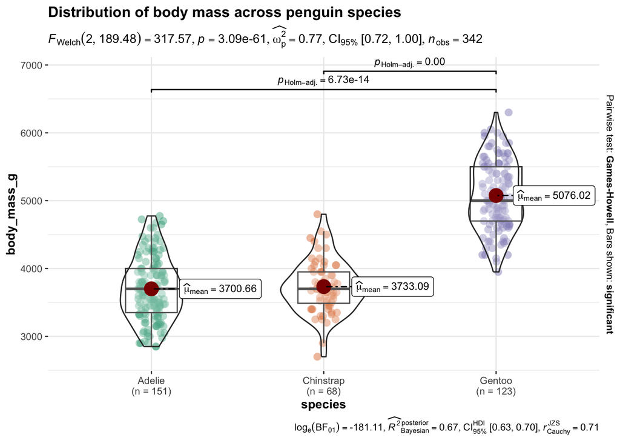

```r
# run in R console if not installed: install.packages("ggstatsplot")
library(ggstatsplot)
ggbetweenstats(
  data  = penguins,
  x     = species, # the categorical variable you want to compare across
  y     = body_mass_g, # numeric variable you want to compare
  title = "Distribution of body mass across penguin species"
)
```

**How do you read this plot?** The plot (combination of box plot and violin plot) tells you it used a statistical test called Games-Howell to do pairwise comparison tests across the groups you identified. “Bar shown: significant” tells you that pairwise differences via pairwise comparison with bars above were found to be statistically significant and there are two bars with p-values (this tells you that difference in two pairwise comparisons are statistically significant).

**Formal statistical interpretation:** The difference in body mass between Adelie and Gentoo (average of 3700 grams vs 5076 grams) is statistically significant. Likewise, the difference in body mass between Chinstrap and Gentoo (average of 3733 grams vs 5076 grams) is statistically significant.

## `ggstatsplot:` **two groups only**

Here’s another code that uses penguins. This time, it only compares two groups via sex (Female vs Male penguins).

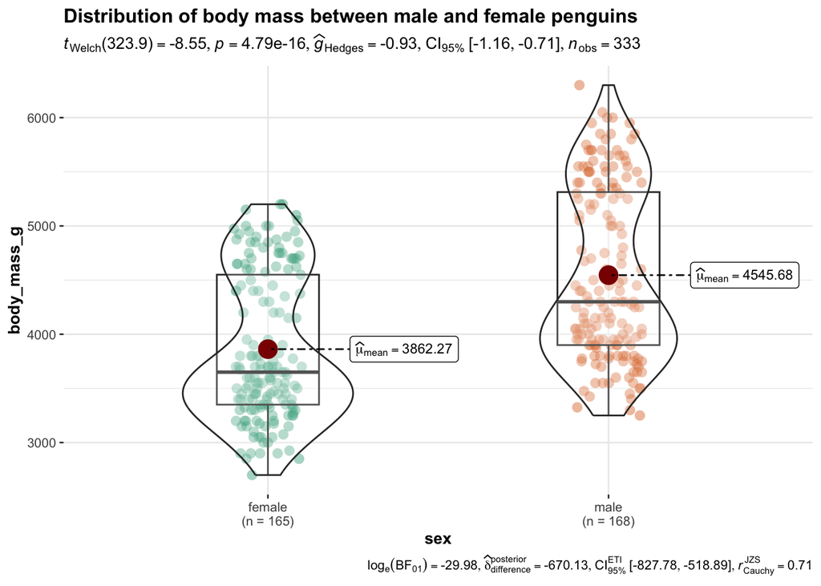

```r
ggbetweenstats(
  data  = penguins,
  x     = sex, # the categorical variable you want to compare across
  y     = body_mass_g, # numeric variable you want to compare
  title = "Distribution of body mass between male and female penguins"
)
```

Important note: Since there are two groups only, you should not expect a bar above to assess pairwise differences. Instead, look at the p-value provided below the graph title. Since p-value provided is 4.79e-16, which is lower than 0.05, the difference in body mass between male and female penguins is statistically significant.

## Practice 5 (3 pts)

Using the ggbetweenstats package, assess whether or not there is a statistically significant difference in **bill_length_mm** across the three islands:

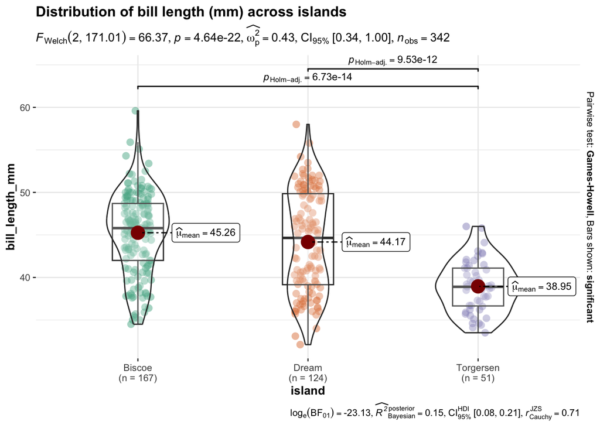

```r
# Your code below
ggbetweenstats(
  data  = penguins,
  x     = island, # the categorical variable you want to compare across
  y     = bill_length_mm, # numeric variable you want to compare
  title = "Distribution of bill length (mm) across islands"
)
```

## Additional note: nonparametric statistics

Typical statistical tests we employ have what are called parametric assumptions (e.g., variable distribution of our sample comes from a population that is bell curved or normally distributed). Again, this is not a statistics class. But if you want to be on the safer side, you can specify `ggbetweenstats()` to use what are called non-parametric statistical tests to compare the groups. If the data you use has a lot of outliers or very skewed, including `type = "nonparametric"` inside `ggbetweenstats()` might be a good idea. Non-parametric tests typically compare the median instead of the mean to assess whether the difference in median across groups are statistically significant.

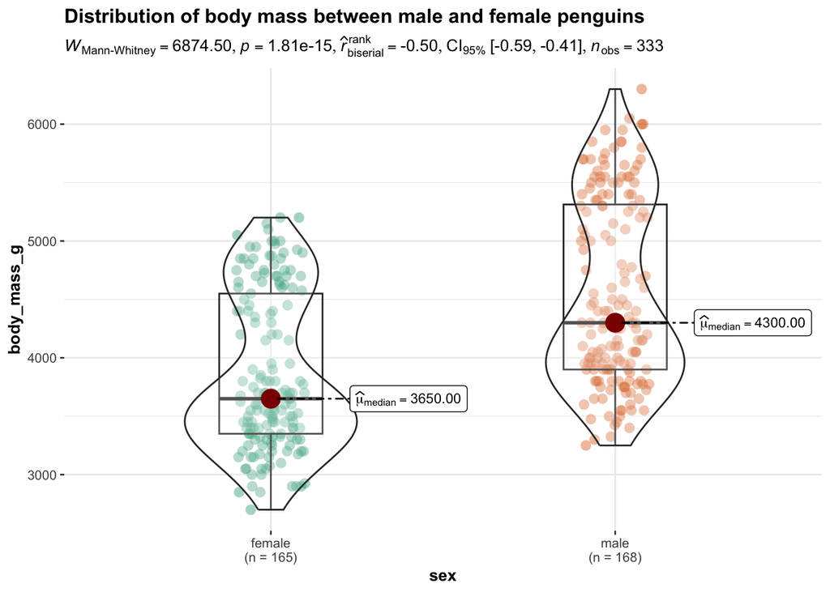

```r
ggbetweenstats(
  data  = penguins,
  x     = sex, # the categorical variable you want to compare across
  y     = body_mass_g, # numeric variable you want to compare
  type = "nonparametric",
  title = "Distribution of body mass between male and female penguins"
)
```